# Geographic concentration of cases

Author

Alexander W. Gofton & Emily Smith

Published

March 13, 2026

## Setup

Load CSIRO colour palette and required packages for spatial analysis, data manipulation, and plot composition.

```r
# Setup
source("code/CSIRO_colours.R")

library(sf)
library(tidyverse)
library(patchwork)
```

# Load Data

Import the deduplicated and full testing datasets, plus the SA3-level case rate summary.

```r
data_no_multi <- read.csv("data/preprocessed_with_SA_info_no_multi.csv") %>%
  filter(YOT >= 2014 & YOT <= 2024)

data_with_multi <- read.csv("data/preprocessed_with_SA_info.csv") %>%
  filter(YOT >= 2014 & YOT <= 2024)
```

```r
sa3_cases_pop <- read.csv("data/SA3_cases_data.csv")
```

# Rank SA3 Regions by Case Rate

Rank SA3 regions by their incidence rate (cases per 1M person-years), excluding regions with very low populations, and calculate cumulative case percentages to assess geographic concentration.

```r
# Rank SA3 regions by cumulative positive cases (2014-2024)
case_concentration_analysis <- sa3_cases_pop %>%
  # Removing SA3s with very low populations and over inflated rates
  filter(
    SA_name != "Canberra East",
    SA_name != "Norfolk Island"
  ) %>%
  filter(!is.na(c1MPPY)) %>%
  arrange(desc(c1MPPY)) %>%
  mutate(
    rank = row_number(),
    cumulative_cases = cumsum(c1MPPY),
    total_cases = sum(c1MPPY, na.rm = TRUE),
    cumulative_percentage = (cumulative_cases / total_cases) * 100,
    regions_percentage = (rank / n()) * 100
  ) %>%
  dplyr::select(
    SA_name,
    rank,
    c1MPPY,
    cumulative_cases,
    cumulative_percentage,
    regions_percentage
  )
```

## Percentile Thresholds

Determine how many top-ranked regions account for 25%, 50%, 75%, 90%, and 95% of all cases.

```r
# Find key percentile thresholds
percentile_thresholds <- tibble(
  percentile = c(25, 50, 75, 90, 95),
  threshold_cases = map_dbl(
    percentile,
    ~ {
      case_concentration_analysis %>%
        filter(cumulative_percentage >= .x) %>%
        slice_head(n = 1) %>%
        pull(cumulative_cases)
    }
  ),
  regions_needed = map_dbl(
    percentile,
    ~ {
      case_concentration_analysis %>%
        filter(cumulative_percentage >= .x) %>%
        slice_head(n = 1) %>%
        pull(rank)
    }
  ),
  percent_of_regions = map_dbl(
    percentile,
    ~ {
      case_concentration_analysis %>%
        filter(cumulative_percentage >= .x) %>%
        slice_head(n = 1) %>%
        pull(regions_percentage)
    }
  )
) %>%
  mutate(
    total_regions = nrow(case_concentration_analysis),
    summary = paste0(
      percentile,
      "% of cases occur in the top ",
      regions_needed,
      " regions (",
      round(percent_of_regions, 1),
      "% of all regions)"
    )
  )
```

## Display Concentration Results

Print the concentration analysis summary showing the number of regions needed to capture each percentile of total cases.

```r
# Display the results
cat("=== CASE CONCENTRATION ANALYSIS ===\n")
print(
  percentile_thresholds %>%
    dplyr::select(percentile, regions_needed, percent_of_regions, summary)
)
```

```
=== CASE CONCENTRATION ANALYSIS ===
# A tibble: 5 × 4
  percentile regions_needed percent_of_regions summary
       <dbl>          <dbl>              <dbl> <chr>
1         25              4               1.19 25% of cases occur in the top 4 …
2         50              9               2.68 50% of cases occur in the top 9 …
3         75             26               7.74 75% of cases occur in the top 26…
4         90             68              20.2  90% of cases occur in the top 68…
5         95            100              29.8  95% of cases occur in the top 10…
```

## Top Regions by Case Rate

Display the 50 highest-ranked SA3 regions by cases per 1M person-years with their cumulative contribution.

```r
# Show top 10 regions with highest case counts
cat("\n=== TOP 10 REGIONS BY CASE COUNT ===\n")
print(
  case_concentration_analysis %>%
    head(50) %>%
    dplyr::select(rank, SA_name, c1MPPY, cumulative_percentage)
)
```

```
=== TOP 10 REGIONS BY CASE COUNT ===
   rank                        SA_name    c1MPPY cumulative_percentage
1     1                      Pittwater 704.00568              10.88544
2     2          Gold Coast Hinterland 440.01375              17.68899
3     3                  Coffs Harbour 431.38091              24.35906
4     4      Sunshine Coast Hinterland 402.75219              30.58648
5     5   Richmond Valley - Hinterland 384.09176              36.52536
6     6      Richmond Valley - Coastal 275.32217              40.78243
7     7                      Warringah 261.60641              44.82742
8     8                    Ku-ring-gai 211.05000              48.09071
9     9                    South Coast 198.72063              51.16336
10   10                     Shoalhaven 183.76358              54.00473
11   11               Noosa Hinterland 160.32309              56.48367
12   12                        Hornsby 159.88085              58.95577
13   13             Kempsey - Nambucca 140.22245              61.12391
```

[output cut: 37 more lines]

# Plotting Case Geographic Concentration

Visualise the geographic concentration of alpha-gal cases using Lorenz-style concentration curves and ranked bar charts.

```r
theme_set(
  theme_classic() +
    theme(
      panel.grid.major = element_line(
        colour = "grey70",
        linewidth = 0.1
      ),
      panel.grid.minor = element_blank(),
      axis.text.x = element_text(size = 11),
      axis.text.y = element_text(size = 11),
      axis.title.y = element_text(size = 12),
      axis.title.x = element_text(size = 12),
      axis.line = element_line(colour = "grey60"),
      axis.ticks = element_line(colour = "grey60"),
      text = element_text(family = "Arial")
    )
)
```

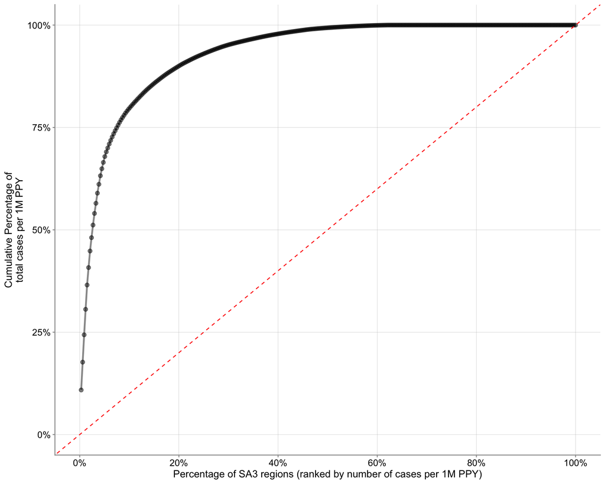

```r
# Create visualization of case concentration
concentration_plot <- case_concentration_analysis %>%
  ggplot(aes(x = regions_percentage, y = cumulative_percentage)) +
  geom_line(color = "grey60", size = 1) +
  geom_point(color = "black", size = 2, alpha = 0.5) +
  geom_abline(
    intercept = 0,
    slope = 1,
    linetype = "dashed",
    color = "red"
  ) +
  scale_x_continuous(
    breaks = seq(0, 100, 20),
    limits = c(0, 100),
    #expand = c(0, 0),
    labels = function(x) paste0(x, "%")
  ) +
  scale_y_continuous(
    breaks = seq(0, 100, 25),
    limits = c(0, 100),
    #expand = c(0, 0),
    labels = function(x) paste0(x, "%")
  ) +
  labs(
    x = "Percentage of SA3 regions (ranked by number of cases per 1M PPY)",
    y = "Cumulative Percentage of\ntotal cases per 1M PPY"
  )

print(concentration_plot)
```

```r
# Save the plot
ggsave(
  "plots/Final_Plots/case_concentration_analysis.png",
  concentration_plot,
  width = 18,
  height = 18,
  units = "cm",
  bg = "white",
  dpi = 300
)
```

## Pareto Chart

Create a Pareto chart showing the top 30 SA3 regions by case rate with a cumulative percentage overlay line.

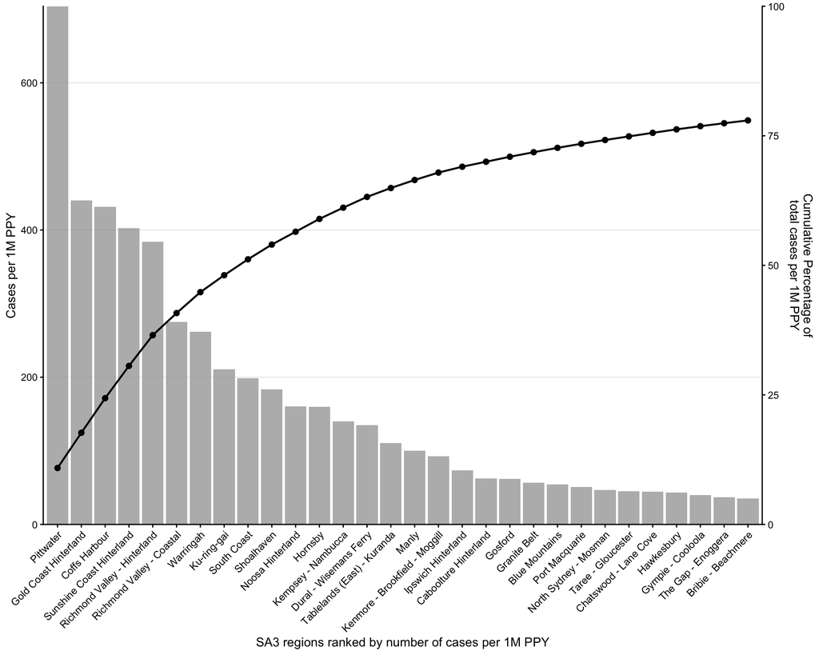

```r
pareto_plot <- case_concentration_analysis %>%
  head(30) %>% # Top 30 regions
  ggplot(aes(x = reorder(SA_name, -c1MPPY))) +
  geom_col(aes(y = c1MPPY), fill = "#999999", alpha = 0.7) +
  geom_line(
    aes(y = cumulative_percentage * max(c1MPPY) / 100, group = 1),
    color = "black",
    size = 0.8
  ) +
  geom_point(
    aes(y = cumulative_percentage * max(c1MPPY) / 100),
    color = "black",
    size = 2
  ) +
  scale_y_continuous(
    name = "Cases per 1M PPY",
    sec.axis = sec_axis(
      trans = ~ . * 100 / max(case_concentration_analysis$c1MPPY[1:30]),
      name = "Cumulative Percentage of\ntotal cases per 1M PPY"
    ),
    expand = c(0, 0)
  ) +
  labs(x = "SA3 regions ranked by number of cases per 1M PPY") +
  theme_classic() +
  theme(
    axis.text.x = element_text(angle = 45, hjust = 1, size = 9),
    panel.grid.minor = element_blank(),
    panel.grid.major.x = element_blank(),
    panel.grid.major.y = element_line(
      colour = "grey70",
      linewidth = 0.1
    )
  )

# Print plot
print(pareto_plot)
```

```r
# Save the plot
ggsave(
  "plots/SA3_region_cases_and_cumulitive.png",
  pareto_plot,
  height = 10,
  width = 20,
  units = "cm",
  bg = "white",
  dpi = 300
)
```

## Combined Concentration Figure

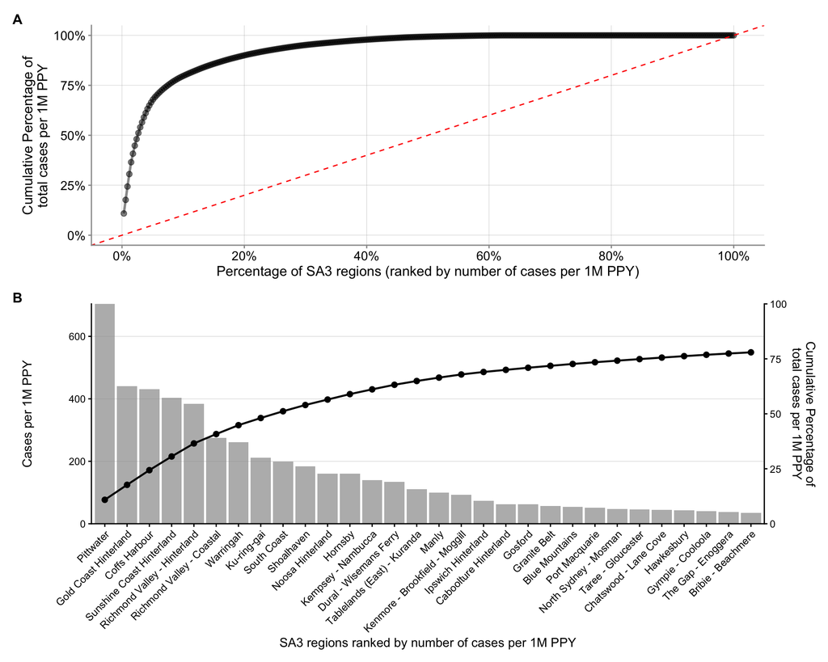

```r
# Combine plots
combined_conc_plot <- (concentration_plot / pareto_plot) +
  plot_annotation(tag_levels = 'A') &
  theme(plot.tag = element_text(face = "bold", size = 12))

combined_conc_plot
```

```r
ggsave(
  "plots/Final_Plots/Fig_4_case_concentration.png",
  combined_conc_plot,
  height = 25,
  width = 24,
  units = "cm",
  bg = "white",
  dpi = 300
)
```

# Gini Coefficient

Calculate the Gini coefficient with bootstrap 95% confidence intervals to quantify the degree of geographic inequality in case distribution.

```r
# Gini coefficient calculation with bootstrap CI
library(boot)

# Function to calculate Gini coefficient for bootstrap
gini_boot <- function(data, indices) {
  d <- data[indices, ]

  gini_calc <- d %>%
    arrange(c1MPPY) %>%
    mutate(
      cumsum_cases = cumsum(c1MPPY),
      cumsum_prop = cumsum_cases / sum(c1MPPY),
      prop_regions = row_number() / n()
    ) %>%
    summarise(
      lorenz_area = sum(
        (prop_regions - lag(prop_regions, default = 0)) *
          (cumsum_prop + lag(cumsum_prop, default = 0)) /
          2
      ),
      gini = (0.5 - lorenz_area) / 0.5
    ) %>%
    pull(gini)

  return(gini_calc)
}

# Run bootstrap
set.seed(7990)
gini_boot_result <- boot(
  data = case_concentration_analysis,
  statistic = gini_boot,
  R = 10000
)

# Calculate 95% CI
gini_ci <- boot.ci(gini_boot_result, type = "bca")

cat("\n=== GINI COEFFICIENT WITH 95% CI ===\n")
cat("Gini Coefficient:", round(gini_boot_result$t0, 3), "\n")
cat(
  "95% CI: [",
  round(gini_ci$bca[4], 3),
  ", ",
  round(gini_ci$bca[5], 3),
  "]\n",
  sep = ""
)
cat("SE:", round(sd(gini_boot_result$t), 4), "\n")
```

```
=== GINI COEFFICIENT WITH 95% CI ===
Gini Coefficient: 0.866
95% CI: [0.837, 0.894]
SE: 0.0159
```

# Spatial Autocorrelation (Global Moran’s I)

Test for spatial clustering of case rates across SA3 regions using Moran’s I statistic with queen-contiguity spatial weights.

```r
library(spdep)

sa3 <- st_read("data/SA3_case_data.shp")

# Calculate case rates for spatial analysis
sa3_with_rates <- sa3_cases_pop %>%
  filter(!is.na(c1MPPY), c1MPPY > 0) %>%
  left_join(
    sa3 %>% dplyr::select(SA_code),
    by = "SA_code"
  ) %>%
  st_as_sf()

# Create spatial weights matrix (neighbors)
sa3_neighbors <- poly2nb(sa3_with_rates, queen = TRUE)
sa3_weights <- nb2listw(sa3_neighbors, style = "W", zero.policy = TRUE)

# Calculate Moran's I
morans_i <- moran.test(sa3_with_rates$c1MPPY, sa3_weights, zero.policy = TRUE)

cat("=== MORAN'S I SPATIAL AUTOCORRELATION ===\n")
print(morans_i)
cat("\nInterpretation:\n")
cat("  Moran's I =", round(morans_i$estimate[1], 3), "\n")
cat("  Expected I =", round(morans_i$estimate[2], 3), "\n")
cat("  p-value =", format.pval(morans_i$p.value, digits = 3), "\n")
cat(
  "  ",
  ifelse(
    morans_i$p.value < 0.05 & morans_i$estimate[1] > 0,
    "Significant positive spatial clustering detected",
    "No significant spatial clustering"
  ),
  "\n"
)
```

```
=== MORAN'S I SPATIAL AUTOCORRELATION ===

    Moran I test under randomisation

data:  sa3_with_rates$c1MPPY
weights: sa3_weights
n reduced by no-neighbour observations

Moran I statistic standard deviate = 5.545, p-value = 1.47e-08
alternative hypothesis: greater
sample estimates:
Moran I statistic       Expectation          Variance
      0.305922641      -0.004975124       0.003143640


Interpretation:
  Moran's I = 0.306
  Expected I = -0.005
  p-value = 1.47e-08
   Significant positive spatial clustering detected
```

# Local Spatial Analysis (LISA and Getis-Ord Gi*)

Identify statistically significant local clusters (hot spots and cold spots) and spatial outliers using Local Moran’s I and Getis-Ord Gi* statistics.

```r
# Calculate local Moran's I (LISA)
local_morans <- localmoran(
  sa3_with_rates$c1MPPY,
  sa3_weights,
  zero.policy = TRUE
)

# Add to spatial data
sa3_with_rates$local_morans_i <- local_morans[, 1]
sa3_with_rates$local_p_value <- local_morans[, 5]

# Classify regions as hot spots, cold spots, or not significant
sa3_with_rates <- sa3_with_rates %>%
  mutate(
    cluster_type = case_when(
      local_p_value >= 0.05 ~ "Not Significant",
      local_morans_i > 0 &
        c1MPPY > mean(c1MPPY, na.rm = TRUE) ~ "High-High (Hot Spot)",
      local_morans_i > 0 &
        c1MPPY < mean(c1MPPY, na.rm = TRUE) ~ "Low-Low (Cold Spot)",
      local_morans_i < 0 &
        c1MPPY > mean(c1MPPY, na.rm = TRUE) ~ "High-Low (Outlier)",
      TRUE ~ "Low-High (Outlier)"
    )
  )

# Calculate Getis-Ord Gi* (alternative hot spot statistic)
getis_ord <- localG(sa3_with_rates$c1MPPY, sa3_weights, zero.policy = TRUE)
sa3_with_rates$gi_star <- as.numeric(getis_ord)
sa3_with_rates$gi_hotspot <- ifelse(
  abs(sa3_with_rates$gi_star) > 1.96,
  "Hot/Cold Spot",
  "Not Significant"
)

cat("\n=== HOT SPOT SUMMARY ===\n")
table(sa3_with_rates$cluster_type)
table(sa3_with_rates$gi_hotspot)
```

```
=== HOT SPOT SUMMARY ===

High-High (Hot Spot)   Low-High (Outlier)      Not Significant
                   8                   19                  184

  Hot/Cold Spot Not Significant
             18             184
```

## Nearest Neighbour Analysis

Calculate distances between centroids of high-case SA3 regions to assess spatial proximity of case clusters.

```r
# Get centroids of high-case regions
high_case_regions <- sa3_with_rates %>%
  filter(c1MPPY > quantile(c1MPPY, 0.75, na.rm = TRUE)) %>%
  st_centroid()

# Calculate distance matrix
dist_matrix <- st_distance(high_case_regions)

# Calculate mean nearest neighbor distance
nearest_neighbor_dist <- apply(
  as.matrix(dist_matrix),
  1,
  function(x) min(x[x > 0])
)

cat("\n=== NEAREST NEIGHBOR ANALYSIS ===\n")
cat(
  "Mean distance between high-case regions:",
  round(mean(nearest_neighbor_dist) / 1000, 1),
  "km\n"
)
cat("Median distance:", round(median(nearest_neighbor_dist) / 1000, 1), "km\n")
```

```
=== NEAREST NEIGHBOR ANALYSIS ===
Mean distance between high-case regions: 71 km
Median distance: 37.1 km
```

# Do Referring Clinicians Drive Case Clustering?

Investigate whether the geographic concentration of positive cases is driven by the location of referring clinicians rather than true disease prevalence.

## Data Preparation

Exclude DHM records (which lack referring clinician postcodes) for this analysis.

```r
data <- data_no_multi %>%
  filter(Provider != 'DHM') # DHM data does not have ref pc
```

## Mapping Postcodes to SA2 Regions

Convert both patient and referring clinician postcodes to SA2 regions using an ABS concordance file to enable spatial analysis at a finer geographic scale.

```r
# Convert postcodes to SA2 regions
# Enables population adjusting

pc_2_sa2 <- read.csv("ABS_shapefiles/postcodes_to_SA/postcodes_2_SA2.csv") %>%
  dplyr::select(postcode, SA2_code, SA2_name, SA3_code, SA3_name) %>%
  mutate(postcode = as.integer(postcode))

# Ref pc to sa2
data_no_multi_sa2 <- data_no_multi %>%
  left_join(
    pc_2_sa2,
    by = c("ref_pc" = "postcode")
  ) %>%
  rename(
    ref_SA2_code = SA2_code,
    ref_SA2_name = SA2_name,
    #ref_SA3_code = SA3_code,
    #ref_SA3_name = SA3_name
  ) %>%
  mutate(postcode = as.integer(postcode))

# Pat pc to sa2
data_no_multi_sa2 <- data_no_multi_sa2 %>%
  left_join(
    pc_2_sa2,
    by = c("postcode" = "postcode")
  ) %>%
  rename(
    pat_SA2_code = SA2_code,
    pat_SA2_name = SA2_name,
    pat_SA3_code = SA3_code,
    pat_SA3_name = SA3_name
  )
```

## Population-Adjusted Counts per SA2

Calculate cumulative patient and referral counts per SA2 region and adjust for population to derive rates per million person-years.

### Patient SA2 Counts

Count unique tested and positive patients per SA2 region based on patient postcode.

```r
## SA2
# Cumulative number of people tested
cum_pat_tes_sa2 <- data_no_multi_sa2 %>%
  group_by(pat_SA2_name) %>%
  summarise(cum_pat_tes_sa2 = n_distinct(pat_ID), .groups = "drop")

# Cumulative number of positives
cum_pat_pos_sa2 <- data_no_multi_sa2 %>%
  filter(Status == "Positive") %>%
  group_by(pat_SA2_name) %>%
  summarise(cum_pat_pos_sa2 = n_distinct(pat_ID), .groups = "drop")
```

### Referring Clinician SA2 Counts

Count unique tested and positive patients per SA2 region based on referring clinician postcode.

```r
## SA2
# Cumulative number of people tested
cum_ref_tes_sa2 <- data_no_multi_sa2 %>%
  group_by(ref_SA2_name) %>%
  summarise(cum_ref_tes_sa2 = n_distinct(pat_ID), .groups = "drop")

# Cumulative number of positives
cum_ref_pos_sa2 <- data_no_multi_sa2 %>%
  filter(Status == "Positive") %>%
  group_by(ref_SA2_name) %>%
  summarise(cum_ref_pos_sa2 = n_distinct(pat_ID), .groups = "drop")
```

```r
sa2_sum <- cum_pat_tes_sa2 %>%
  full_join(cum_pat_pos_sa2, by = "pat_SA2_name") %>%
  full_join(cum_ref_tes_sa2, by = c("pat_SA2_name" = "ref_SA2_name")) %>%
  full_join(cum_ref_pos_sa2, by = c("pat_SA2_name" = "ref_SA2_name")) %>%
  rename(SA2_name = pat_SA2_name)

glimpse(sa2_sum)
```

```
Rows: 578
Columns: 5
$ SA2_name        <chr> "Adamstown - Kotara", "Adelaide Hills", "Agnes Water -…
$ cum_pat_tes_sa2 <int> 1, 1, 5, 15, 2, 6, 4, 1, 4, 16, 1, 9, 2, 14, 2, 3, 22,…
$ cum_pat_pos_sa2 <int> NA, 1, 2, 3, 1, 1, 2, NA, NA, 4, NA, 3, 1, 1, NA, 2, 1…
$ cum_ref_tes_sa2 <int> 1, NA, NA, 23, NA, NA, 3, NA, 10, 3, NA, 2, NA, 171, N…
$ cum_ref_pos_sa2 <int> 1, NA, NA, 2, NA, NA, NA, NA, 7, 2, NA, NA, NA, 73, NA…
```

### Merging Population Data

Join ABS SA2 population estimates and calculate cumulative person-years for rate computation.

```r
## SA2
# Adding population data
pop <- read.csv("ABS_population_data/SA2_population.csv") %>%
  dplyr::select(-p2013) %>%
  mutate(
    total_pop_14_24 = p2014 +
      p2015 +
      p2016 +
      p2017 +
      p2018 +
      p2019 +
      p2020 +
      p2021 +
      p2022 +
      p2023 +
      p2024
  )

sa2_sum <- sa2_sum %>%
  left_join(
    pop,
    by = "SA2_name"
  ) %>%
  dplyr::select(SA2_name, SA2_code, cum_pat_tes_sa2:cum_ref_pos_sa2, total_pop_14_24)
```

### Calculating SA2 Rates

Compute population-adjusted testing and case rates (per 1M person-years) for both patient and referring perspectives.

```r
## SA2
sa2_sum <- sa2_sum %>%
  mutate(
    P_t1MPPY = (cum_pat_tes_sa2 / total_pop_14_24) * 1000000,
    P_c1MPPY = (cum_pat_pos_sa2 / total_pop_14_24) * 1000000,
    R_t1MPPY = (cum_ref_tes_sa2 / total_pop_14_24) * 1000000,
    R_c1MPPY = (cum_ref_pos_sa2 / total_pop_14_24) * 1000000,
  )
```

## Referring Postcode Case Concentration

Analyse how concentrated positive cases are across referring clinician postcodes.

```r
ref_pc_cases <- data_no_multi %>%
  filter(Provider != "DHM") %>%
  group_by(ref_pc) %>%
  summarise(
    n_tests = n(),
    n_pos = sum(Status == "Positive", na.rm = TRUE),
    .groups = "drop"
  ) %>%
  arrange(desc(n_pos)) %>%
  mutate(
    cumulative_tests = cumsum(n_tests),
    cumulative_tests_pct = cumulative_tests / sum(n_tests) * 100,
    rank_tests = row_number(),
    #
    cumulative_pos = cumsum(n_pos),
    cumulative_pos_pct = cumulative_pos / sum(n_pos) * 100,
    rank_pos = row_number()
  )

# Save summary of referring postcode case concentration
write.csv(
  ref_pc_cases,
  "results/ref_postcode_case_summary.csv",
  row.names = FALSE
)
```

### Global Moran’s I for Referring SA2 Regions

Test for spatial clustering of referral-based case rates at the SA2 level.

```r
select <- dplyr::select
```

```r
sa2_sf <- read_sf(
  "ABS_shapefiles/SA2_2021_AUST_SHP_GDA2020/SA2_2021_AUST_GDA2020.shp"
)
```

```r
# Prepare spatial data for referring SA2 regions
# Join sa2_sum (which contains referring statistics) with sa2_sf (spatial features)
ref_sa2_spatial <- sa2_sum %>%
  filter(!is.na(R_c1MPPY), R_c1MPPY > 0, cum_ref_pos_sa2 > 0) %>%
  mutate(SA2_code = as.character(SA2_code)) %>%
  # Join with spatial features - check column names in sa2_sf (typically SA2_CODE21 or SA2_CODE_2021)
  left_join(
    sa2_sf %>% select(SA2_CODE21, SA2_NAME21, geometry),
    by = c("SA2_code" = "SA2_CODE21")
  ) %>%
  filter(!is.na(geometry)) %>% # Remove SA2s without spatial match
  st_as_sf()

# Check how many SA2 regions we have
cat("Number of SA2 regions with referring data:", nrow(ref_sa2_spatial), "\n")
```

```
Number of SA2 regions with referring data: 214
```

```r
# Create spatial weights matrix (queen contiguity) for referring SA2 regions
ref_neighbors <- poly2nb(ref_sa2_spatial, queen = TRUE)
ref_weights <- nb2listw(ref_neighbors, style = "W", zero.policy = TRUE)

# Check connectivity
cat("Spatial weights matrix created\n")
cat("Number of regions:", length(ref_neighbors), "\n")
cat("Average neighbors per region:", round(mean(card(ref_neighbors)), 2), "\n")
```

```
Spatial weights matrix created
Number of regions: 214
Average neighbors per region: 1.62
```

```r
# Calculate global Moran's I for REFERRING SA2 regions
# Using R_c1MPPY (referring positive cases per million per year)
# Check for regions with no neighbors
no_neighbors <- card(ref_neighbors)
isolated_regions <- which(no_neighbors == 0)

cat("Number of isolated regions:", length(isolated_regions), "\n")

if (length(isolated_regions) > 0) {
  cat("Removing", length(isolated_regions), "isolated regions\n")

  # Remove isolated regions
  ref_sa2_spatial_clean <- ref_sa2_spatial[-isolated_regions, ]

  # Recreate spatial weights
  ref_neighbors_clean <- poly2nb(ref_sa2_spatial_clean, queen = TRUE)
  ref_weights_clean <- nb2listw(
    ref_neighbors_clean,
    style = "W",
    zero.policy = TRUE
  )

  # Recalculate Moran's I
  morans_ref <- moran.test(
    ref_sa2_spatial_clean$R_c1MPPY,
    ref_weights_clean,
    zero.policy = TRUE
  )

  cat("\nREFERRING SA2 Moran's I Analysis (cleaned):\n")
  cat("  Moran's I =", round(morans_ref$estimate[1], 3), "\n")
  cat("  Expected I =", round(morans_ref$estimate[2], 3), "\n")
  cat("  Variance =", round(morans_ref$estimate[3], 6), "\n")
  cat("  p-value =", format.pval(morans_ref$p.value, digits = 3), "\n")
}
cat(
  "  Interpretation:",
  ifelse(
    morans_ref$p.value < 0.05 & morans_ref$estimate[1] > 0,
    "Significant positive spatial clustering",
    ifelse(
      morans_ref$p.value < 0.05 & morans_ref$estimate[1] < 0,
      "Significant negative spatial clustering (dispersion)",
      "No significant spatial clustering"
    )
  ),
  "\n"
)
```

```
Number of isolated regions: 67
Removing 67 isolated regions

REFERRING SA2 Moran's I Analysis (cleaned):
  Moran's I = -0.005
  Expected I = -0.007
  Variance = 0.000113
  p-value = 0.429
  Interpretation: No significant spatial clustering
```

### Global Moran’s I for Patient SA2 Regions

Test for spatial clustering of patient-based case rates at the SA2 level for comparison with the referring analysis.

```r
# Calculate Moran's I for PATIENT SA2 regions (for this specific subset of data)
# This is important because this dataset only includes records with referring clinician postcodes
pat_sa2_spatial <- sa2_sum %>%
  filter(!is.na(P_c1MPPY), P_c1MPPY > 0, cum_pat_pos_sa2 > 0) %>%
  filter(is.finite(P_c1MPPY)) %>% # Add this line to remove Inf/-Inf
  mutate(SA2_code = as.character(SA2_code)) %>%
  left_join(
    sa2_sf %>% select(SA2_CODE21, SA2_NAME21, geometry),
    by = c("SA2_code" = "SA2_CODE21")
  ) %>%
  filter(!is.na(geometry)) %>%
  st_as_sf()

# Create spatial weights for patient SA2
pat_neighbors <- poly2nb(pat_sa2_spatial, queen = TRUE)
pat_weights <- nb2listw(pat_neighbors, style = "W", zero.policy = TRUE)

# Calculate Moran's I for patient data
morans_pat <- moran.test(
  pat_sa2_spatial$P_c1MPPY,
  pat_weights,
  zero.policy = TRUE
)

cat("\nPATIENT SA2 Moran's I Analysis (for this subset):\n")
cat("  Moran's I =", round(morans_pat$estimate[1], 3), "\n")
cat("  Expected I =", round(morans_pat$estimate[2], 3), "\n")
cat("  p-value =", format.pval(morans_pat$p.value, digits = 3), "\n")
cat(
  "  Interpretation:",
  ifelse(
    morans_pat$p.value < 0.05 & morans_pat$estimate[1] > 0,
    "Significant positive spatial clustering",
    "No significant spatial clustering"
  ),
  "\n"
)
```

```
PATIENT SA2 Moran's I Analysis (for this subset):
  Moran's I = -0.025
  Expected I = -0.004
  p-value = 0.699
  Interpretation: No significant spatial clustering
```

### Spatial Clustering Comparison

Compare Moran’s I values between patient and referring SA2 regions to assess whether clinician behaviour contributes to observed case clustering.

```r
# Comparison and epidemiological interpretation
cat("\n==========================================\n")
cat("=== SPATIAL AUTOCORRELATION COMPARISON ===\n")
cat("==========================================\n\n")

cat("Patient SA2 Moran's I:", round(morans_pat$estimate[1], 3), "\n")
cat("Referring SA2 Moran's I:", round(morans_ref$estimate[1], 3), "\n\n")

# Calculate ratio
ratio <- morans_ref$estimate[1] / morans_pat$estimate[1]
cat("Ratio (Referring/Patient):", round(ratio, 3), "\n\n")

# Epidemiological interpretation
cat("=== EPIDEMIOLOGICAL INTERPRETATION ===\n\n")

if (morans_pat$p.value >= 0.05) {
  cat("⚠ WARNING: Patient SA2 clustering is not statistically significant.\n")
  cat("   Cannot draw strong conclusions about clinician effect.\n\n")
} else if (morans_ref$p.value >= 0.05) {
  cat("✓ STRONG EVIDENCE FOR CLINICIAN EFFECT:\n")
  cat(
    "   - Patient SA2s show significant clustering (Moran's I = ",
    round(morans_pat$estimate[1], 3),
    ")\n",
    sep = ""
  )
  cat(
    "   - Referring SA2s show NO significant clustering (p = ",
    round(morans_ref$p.value, 3),
    ")\n",
    sep = ""
  )
  cat("   - This suggests case clustering is driven by healthcare provider\n")
  cat(
    "     knowledge/behavior rather than true geographic disease prevalence.\n\n"
  )
} else if (ratio < 0.7) {
  cat("✓ MODERATE EVIDENCE FOR CLINICIAN EFFECT:\n")
  cat(
    "   - Referring SA2 clustering is substantially lower than patient clustering\n"
  )
  cat(
    "   - Ratio of ",
    round(ratio, 2),
    " suggests clinicians are geographically dispersed\n",
    sep = ""
  )
  cat(
    "   - This pattern is consistent with specific high-knowledge providers\n"
  )
  cat("     diagnosing cases across broader geographic areas.\n\n")
} else if (ratio > 1.3) {
  cat("✗ HYPOTHESIS NOT SUPPORTED:\n")
  cat(
    "   - Referring SA2 clustering is equal to or higher than patient clustering\n"
  )
  cat("   - This suggests true geographic disease prevalence rather than\n")
  cat("     clinician-driven detection bias.\n\n")
} else {
  cat("? MIXED EVIDENCE:\n")
  cat("   - Similar clustering levels between patient and referring SA2s\n")
  cat(
    "   - Ratio of ",
    round(ratio, 2),
    " suggests both geographic disease prevalence\n",
    sep = ""
  )
  cat("     and clinician factors may contribute to observed patterns.\n")
  cat("   - Further investigation needed (see ANALYSIS 3-5).\n\n")
}
```

```
==========================================
=== SPATIAL AUTOCORRELATION COMPARISON ===
==========================================

Patient SA2 Moran's I: -0.025
Referring SA2 Moran's I: -0.005

Ratio (Referring/Patient): 0.194

=== EPIDEMIOLOGICAL INTERPRETATION ===

⚠ WARNING: Patient SA2 clustering is not statistically significant.
   Cannot draw strong conclusions about clinician effect.
```

## Patient-Clinician SA2 Overlap

Assess how often patients and their referring clinicians are located in the same SA2 region.

```r
# Analyze overlap between patient and referring SA2 regions
same_sa2_analysis <- data_no_multi_sa2 %>%
  filter(!is.na(pat_SA2_code), !is.na(ref_SA2_code)) %>%
  mutate(same_SA2 = pat_SA2_code == ref_SA2_code)

same_sa2_summary <- same_sa2_analysis %>%
  summarise(
    total = n(),
    same_SA2_count = sum(same_SA2),
    diff_SA2_count = sum(!same_SA2),
    pct_same_SA2 = mean(same_SA2) * 100
  )

cat("=== PATIENT-CLINICIAN SA2 OVERLAP ANALYSIS ===\n\n")
cat(
  "Total tests with both patient and clinician SA2:",
  same_sa2_summary$total,
  "\n"
)
cat(
  "Same SA2:",
  same_sa2_summary$same_SA2_count,
  "(",
  round(same_sa2_summary$pct_same_SA2, 1),
  "%)\n"
)
cat(
  "Different SA2:",
  same_sa2_summary$diff_SA2_count,
  "(",
  round(100 - same_sa2_summary$pct_same_SA2, 1),
  "%)\n\n"
)

# Interpretation
if (same_sa2_summary$pct_same_SA2 < 40) {
  cat("✓ Most patients see clinicians outside their SA2 region\n")
  cat("  This suggests cases are driven by specialist knowledge rather than\n")
  cat("  local healthcare availability.\n")
} else if (same_sa2_summary$pct_same_SA2 > 70) {
  cat("✗ Most patients see clinicians within their SA2 region\n")
  cat("  This suggests localized healthcare patterns.\n")
} else {
  cat("? Mixed pattern: moderate cross-regional consultation\n")
}

same_sa2_summary
```

```
=== PATIENT-CLINICIAN SA2 OVERLAP ANALYSIS ===

Total tests with both patient and clinician SA2: 6387
Same SA2: 1946 ( 30.5 %)
Different SA2: 4441 ( 69.5 %)

✓ Most patients see clinicians outside their SA2 region
  This suggests cases are driven by specialist knowledge rather than
  local healthcare availability.
  total same_SA2_count diff_SA2_count pct_same_SA2
1  6387           1946           4441     30.46814
```

```r
# Further breakdown by test result (positive vs negative)
same_sa2_by_status <- same_sa2_analysis %>%
  group_by(Status, same_SA2) %>%
  summarise(count = n(), .groups = "drop") %>%
  pivot_wider(names_from = same_SA2, values_from = count, values_fill = 0) %>%
  mutate(
    total = `TRUE` + `FALSE`,
    pct_same = (`TRUE` / total) * 100
  )

cat("\nOverlap by test result:\n")
print(same_sa2_by_status)
```

```
Overlap by test result:
# A tibble: 3 × 5
  Status   `FALSE` `TRUE` total pct_same
  <chr>      <int>  <int> <int>    <dbl>
1 Negative    2903   1021  3924     26.0
2 Positive    1537    925  2462     37.6
3 <NA>           1      0     1      0
```

## Patient-Clinician Distance Analysis

Calculate the geographic distance between each patient’s postcode and their referring clinician’s postcode to quantify consultation travel distances.

```r
pc_shp <- read_sf(
  "ABS_shapefiles/postcodes_2021_AUST_GDA2020_SHP/POA_2021_AUST_GDA2020.shp"
)

# Calculate centroids for each SA2 region (for distance calculations)
# sa2_centroids <- sa2_sf %>%
#   select(SA2_CODE21, SA2_NAME21, geometry) %>%
#   st_centroid() %>%
#   st_transform(crs = 3577) %>% # Australian Albers for distance calculation
#   rename(SA2_code = SA2_CODE21, SA2_name = SA2_NAME21)

# Calculate centroids for each postcode region (for distance calculations)
pc_centroids <- pc_shp %>%
  select(POA_CODE21, geometry) %>%
  st_centroid() %>%
  st_transform(crs = 3577) %>% # Australian Albers for distance calculation
  rename(postcode = POA_CODE21)

pc_centroids
```

```
Simple feature collection with 2644 features and 1 field (with 3 geometries empty)
Geometry type: POINT
Dimension:     XY
Bounding box:  xmin: -3849236 ymin: -4805663 xmax: 3414988 ymax: -1108503
Projected CRS: GDA94 / Australian Albers
# A tibble: 2,644 × 2
   postcode             geometry
   <chr>             <POINT [m]>
 1 0800     (-127953.8 -1315006)
 2 0810     (-124399.3 -1304968)
 3 0812     (-120200.8 -1305789)
 4 0820     (-125640.7 -1310805)
 5 0822      (97752.81 -1376149)
 6 0828     (-117377.7 -1311262)
 7 0829     (-110468.3 -1313485)
 8 0830     (-106250.6 -1306699)
 9 0832     (-110969.9 -1320388)
10 0834       (-107990 -1324077)
# ℹ 2,634 more rows
```

```r
#
# Calculate distances between patient and clinician postcode centroids
calc_distance_sa2 <- function(pat_pc, ref_pc, centroids) {
  # If same postcode, distance is 0
  if (pat_pc == ref_pc) {
    return(0)
  }

  # Find centroids for both postcodes
  pat_pt <- centroids %>% filter(postcode == pat_pc)
  ref_pt <- centroids %>% filter(postcode == ref_pc)

  # If either postcode not found, return NA
  if (nrow(pat_pt) == 0 | nrow(ref_pt) == 0) {
    return(NA)
  }

  # Calculate distance in km
  dist <- st_distance(pat_pt, ref_pt)[1, 1]
  return(as.numeric(dist) / 1000) # Convert meters to km
}

cat("Distance calculation function created\n")
```

```
Distance calculation function created
```

```r
# Apply distance calculation to all patient-clinician pairs
# Note: This may take a few minutes for large datasets
cat("Calculating distances for", nrow(data_no_multi_sa2), "records...\n")

distances <- data_no_multi_sa2 %>%
  filter(!is.na(pat_SA2_code), !is.na(ref_SA2_code)) %>%
  rowwise() %>%
  mutate(
    distance_km = calc_distance_sa2(postcode, ref_pc, pc_centroids)
  ) %>%
  ungroup()

cat("Distance calculation complete\n")
```

```
Calculating distances for 14076 records...
Distance calculation complete
```

```r
# Distance summary statistics
cat("\n=== PATIENT-CLINICIAN DISTANCE ANALYSIS ===\n\n")
cat("Distance statistics (km):\n")
cat("  Mean:", round(mean(distances$distance_km, na.rm = TRUE), 1), "km\n")
cat("  Median:", round(median(distances$distance_km, na.rm = TRUE), 1), "km\n")
cat("  SD:", round(sd(distances$distance_km, na.rm = TRUE), 1), "km\n")
cat("  Min:", round(min(distances$distance_km, na.rm = TRUE), 1), "km\n")
cat("  Max:", round(max(distances$distance_km, na.rm = TRUE), 1), "km\n\n")

# Distance categories
cat("Distance categories:\n")
cat(
  "  0 km (same SA2):",
  sum(distances$distance_km == 0, na.rm = TRUE),
  "(",
  round(mean(distances$distance_km == 0, na.rm = TRUE) * 100, 1),
  "%)\n"
)
cat(
  "  < 50 km:",
  sum(distances$distance_km > 0 & distances$distance_km < 50, na.rm = TRUE),
  "(",
  round(
    mean(distances$distance_km > 0 & distances$distance_km < 50, na.rm = TRUE) *
      100,
    1
  ),
  "%)\n"
)
cat(
  "  50-100 km:",
  sum(distances$distance_km >= 50 & distances$distance_km < 100, na.rm = TRUE),
  "(",
  round(
    mean(
      distances$distance_km >= 50 & distances$distance_km < 100,
      na.rm = TRUE
    ) *
      100,
    1
  ),
  "%)\n"
)
cat(
  "  > 100 km:",
  sum(distances$distance_km >= 100, na.rm = TRUE),
  "(",
  round(mean(distances$distance_km >= 100, na.rm = TRUE) * 100, 1),
  "%)\n\n"
)

# Epidemiological interpretation
median_dist <- median(distances$distance_km, na.rm = TRUE)
if (median_dist < 20) {
  cat(
    "✗ Most patients see nearby clinicians - suggests local healthcare patterns\n"
  )
} else if (median_dist > 50) {
  cat(
    "✓ Patients often travel long distances - consistent with specialist consultation\n"
  )
} else {
  cat("? Moderate travel distances observed\n")
}
```

```
=== PATIENT-CLINICIAN DISTANCE ANALYSIS ===

Distance statistics (km):
  Mean: 72.7 km
  Median: 14.4 km
  SD: 217.9 km
  Min: 0 km
  Max: 3582.1 km

Distance categories:
  0 km (same SA2): 1778 ( 30.9 %)
  < 50 km: 2651 ( 46.1 %)
  50-100 km: 522 ( 9.1 %)
  > 100 km: 804 ( 14 %)

✗ Most patients see nearby clinicians - suggests local healthcare patterns
```

```r
# Save distance results
write.csv(
  distances,
  "results/patient_clinician_distances_sa2.csv",
  row.names = FALSE
)
```

## Referring Clinician Hot Spots

Identify SA2 regions with significantly elevated referral rates using Getis-Ord Gi* statistics.

```r
# Calculate Getis-Ord Gi* statistic for referring SA2 regions
# This identifies hot spots (clusters of high values) and cold spots (clusters of low values)
getis_ord_ref <- localG(
  ref_sa2_spatial$R_c1MPPY,
  ref_weights,
  zero.policy = TRUE
)

# Add Gi* scores to the spatial dataframe
ref_sa2_spatial$gi_star <- as.numeric(getis_ord_ref)

# Classify hot spots and cold spots (using 95% confidence level, z > 1.96)
ref_sa2_spatial$gi_classification <- case_when(
  ref_sa2_spatial$gi_star > 1.96 ~ "Hot Spot (High)",
  ref_sa2_spatial$gi_star < -1.96 ~ "Cold Spot (Low)",
  TRUE ~ "Not Significant"
)

# Summary of hot/cold spots
gi_summary <- table(ref_sa2_spatial$gi_classification)
cat("Getis-Ord Gi* Classification:\n")
print(gi_summary)
cat("\n")
```

```
Getis-Ord Gi* Classification:

Hot Spot (High) Not Significant
              1             213
```

```r
# Identify potential high-knowledge referring regions
# Criteria: Either high rate (>2x median) OR significant hot spot
median_rate_ref <- median(ref_sa2_spatial$R_c1MPPY, na.rm = TRUE)
high_threshold <- 2 * median_rate_ref

high_knowledge_regions <- ref_sa2_spatial %>%
  st_drop_geometry() %>%
  filter(
    R_c1MPPY > high_threshold | # More than 2x median rate
      gi_star > 1.96 # Significant hot spot (95% confidence)
  ) %>%
  arrange(desc(R_c1MPPY)) %>%
  select(SA2_name, SA2_code, cum_ref_pos_sa2, R_c1MPPY, gi_star, gi_classification)

cat("=== HIGH-KNOWLEDGE CLINICIAN REGIONS ===\n\n")
cat(
  "Threshold: >",
  round(high_threshold, 1),
  "positive cases per million per year\n"
)
cat(
  "Identified",
  nrow(high_knowledge_regions),
  "potential high-knowledge regions\n\n"
)
```

```
=== HIGH-KNOWLEDGE CLINICIAN REGIONS ===

Threshold: > 44.7 positive cases per million per year
Identified 67 potential high-knowledge regions
```

```r
# Display top high-knowledge regions
cat("Top 20 high-knowledge clinician regions:\n\n")
print(
  high_knowledge_regions %>%
    head(20) %>%
    mutate(
      R_c1MPPY = round(R_c1MPPY, 1),
      gi_star = round(gi_star, 2)
    ) %>%
    arrange(desc(cum_ref_pos_sa2))
)

# Summary statistics
cat("\n\nSummary of high-knowledge regions:\n")
cat("  Total positive cases:", sum(high_knowledge_regions$cum_ref_pos_sa2), "\n")
cat(
  "  Mean rate:",
  round(mean(high_knowledge_regions$R_c1MPPY), 1),
  "per million per year\n"
)
cat(
  "  Median rate:",
  round(median(high_knowledge_regions$R_c1MPPY), 1),
  "per million per year\n"
)
```

```
Top 20 high-knowledge clinician regions:

# A tibble: 20 × 6
   SA2_name          SA2_code cum_ref_pos_sa2 R_c1MPPY gi_star gi_classification
   <chr>             <chr>              <int>    <dbl>   <dbl> <chr>
 1 Sawtell - Boambee 1040210…             256    1160.   -0.07 Not Significant
 2 Caloundra Hinter… 3160614…             156    1577.   -0.17 Not Significant
 3 Kelvin Grove - H… 3050311…             146    1222.   -0.11 Not Significant
 4 Mullumbimby       1120112…             143    1494.   -0.12 Not Significant
 5 Ballina           1120112…             135     677.  NaN    Not Significant
 6 Woolloongabba     3030210…             123    1454.   -0.14 Not Significant
 7 Lismore Surrounds 1120212…             116     674.   -0.15 Not Significant
 8 West End          3050111…              93     633.   -0.08 Not Significant
 9 Chapel Hill       3040210…              86     720.  NaN    Not Significant
10 Byron Bay         1120112…              79     676.   -0.07 Not Significant
11 Korora - Emerald… 1040210…              74     690.   -0.08 Not Significant
12 Arundel           3090312…              73     600.  NaN    Not Significant
13 Tamborine - Canu… 3090412…              60     354.   -0.16 Not Significant
14 Chelmer - Gracev… 3040310…              37     424.  NaN    Not Significant
15 Nambucca Heads S… 1080211…              32     363.   -0.07 Not Significant
16 Bangalow          1120112…              21     290.   -0.09 Not Significant
17 Centennial Park   1180113…               5  555556.   -0.13 Not Significant
18 Brisbane Port - … 3010310…               4   38095.   -0.07 Not Significant
19 Ettrema - Sassaf… 1140112…               2    3221.   -0.08 Not Significant
20 Lamb Range        3060211…               1   25641    -0.13 Not Significant


Summary of high-knowledge regions:
  Total positive cases: 2164
  Mean rate: 9560.7 per million per year
  Median rate: 139.5 per million per year
```

```r
# Save high-knowledge regions to CSV
write.csv(
  high_knowledge_regions,
  "results/high_knowledge_regions_sa2.csv",
  row.names = FALSE
)
```

## Referral Hub Analysis

Identify SA2 regions where referring clinicians receive a high proportion of cases from outside their own region, indicating specialist referral patterns.

```r
# Identify SA2 regions that act as referral hubs
# Hubs are defined as regions where clinicians receive many cases from OTHER SA2 regions
referral_hubs <- data_no_multi_sa2 %>%
  filter(!is.na(pat_SA2_code), !is.na(ref_SA2_code)) %>%
  group_by(ref_SA2_code, ref_SA2_name) %>%
  summarise(
    total_cases = n(),
    local_cases = sum(pat_SA2_code == ref_SA2_code),
    remote_cases = sum(pat_SA2_code != ref_SA2_code),
    pct_remote = mean(pat_SA2_code != ref_SA2_code) * 100,
    n_different_patient_SA2s = n_distinct(pat_SA2_code[
      pat_SA2_code != ref_SA2_code
    ]),
    .groups = "drop"
  ) %>%
  filter(total_cases >= 5) %>% # Minimum threshold (lower for SA2 vs SA3)
  arrange(desc(pct_remote))

cat("=== REFERRAL HUB ANALYSIS ===\n\n")
cat(
  "Referral hubs are SA2 regions where clinicians receive cases from many other regions\n"
)
cat(
  "Total referral hub regions identified:",
  nrow(referral_hubs %>% filter(pct_remote > 50)),
  "\n\n"
)

cat("Top 20 referral hubs (by % remote cases):\n\n")
print(
  referral_hubs %>%
    head(20) %>%
    mutate(pct_remote = round(pct_remote, 1)) %>%
    select(
      ref_SA2_name,
      total_cases,
      local_cases,
      remote_cases,
      pct_remote,
      n_different_patient_SA2s
    )
)
```

```
=== REFERRAL HUB ANALYSIS ===

Referral hubs are SA2 regions where clinicians receive cases from many other regions
Total referral hub regions identified: 90

Top 20 referral hubs (by % remote cases):

# A tibble: 20 × 6
   ref_SA2_name                  total_cases local_cases remote_cases pct_remote
   <chr>                               <int>       <int>        <int>      <dbl>
 1 Figtree - Keiraville                    5           0            5        100
 2 Lambton - New Lambton                  12           0           12        100
 3 Newcastle - Cooks Hill                  7           0            7        100
 4 Glenwood                               10           0           10        100
 5 Sydney (North) - Millers Poi…          12           0           12        100
 6 Sydney (South) - Haymarket             10           0           10        100
 7 Annandale (NSW)                        10           0           10        100
 8 Turramurra                              5           0            5        100
 9 Mosman - North                         12           0           12        100
10 Mona Vale - Warriewood (Nort…          16           0           16        100
11 Macquarie Park - Marsfield              5           0            5        100
12 Leppington - Catherine Field           10           0           10        100
13 McDowall                               32           0           32        100
14 South Brisbane                         11           0           11        100
15 Red Hill (Qld)                          7           0            7        100
16 Woree                                   6           0            6        100
17 Robina - East                           7           0            7        100
18 Darra - Sumner                          5           0            5        100
19 Loganholme - Tanah Merah                6           0            6        100
20 Parrearra - Warana                     20           0           20        100
# ℹ 1 more variable: n_different_patient_SA2s <int>
```

```r
# Save Moran's I comparison results
morans_results <- data.frame(
  analysis = c("Patient SA2 (subset)", "Referring SA2"),
  morans_i = c(morans_pat$estimate[1], morans_ref$estimate[1]),
  expected_i = c(morans_pat$estimate[2], morans_ref$estimate[2]),
  p_value = c(morans_pat$p.value, morans_ref$p.value),
  significant = c(morans_pat$p.value < 0.05, morans_ref$p.value < 0.05),
  interpretation = c(
    ifelse(
      morans_pat$p.value < 0.05 & morans_pat$estimate[1] > 0,
      "Significant clustering",
      "No significant clustering"
    ),
    ifelse(
      morans_ref$p.value < 0.05 & morans_ref$estimate[1] > 0,
      "Significant clustering",
      "No significant clustering"
    )
  )
)

write.csv(
  morans_results,
  "results/morans_i_comparison_sa2.csv",
  row.names = FALSE
)

# Save referral hubs
write.csv(referral_hubs, "results/referral_hubs_sa2.csv", row.names = FALSE)

cat("\n\nResults saved:\n")
cat("  - results/morans_i_comparison_sa2.csv\n")
cat("  - results/referral_hubs_sa2.csv\n")
```

```
Results saved:
  - results/morans_i_comparison_sa2.csv
  - results/referral_hubs_sa2.csv
```

# Visualisations

Generate summary plots for patient-clinician distance distributions and concentration curve comparisons.

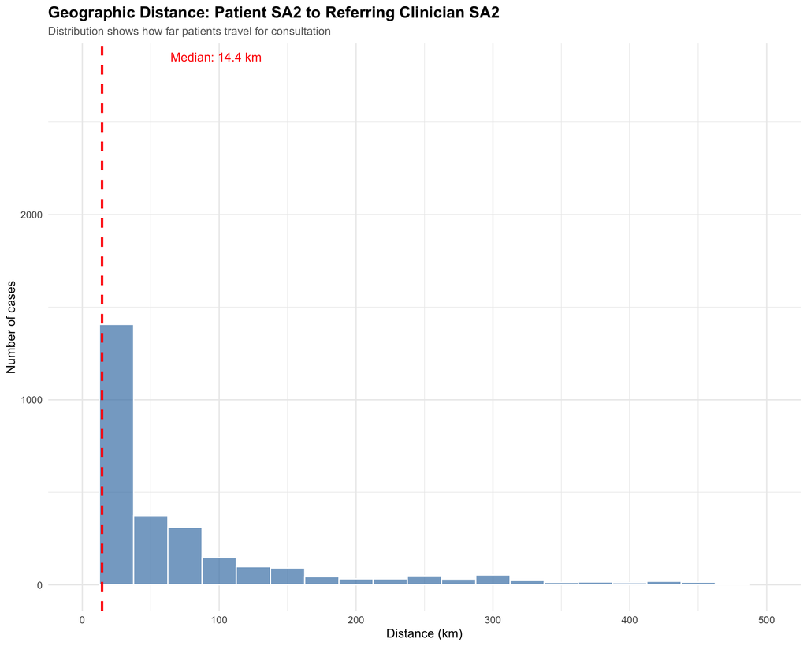

```r
# PLOT 1: Distance distribution between patient and clinician SA2 regions
distance_plot <- ggplot(distances, aes(x = distance_km)) +
  geom_histogram(
    binwidth = 25,
    fill = "steelblue",
    alpha = 0.7,
    color = "white"
  ) +
  geom_vline(
    xintercept = median(distances$distance_km, na.rm = TRUE),
    linetype = "dashed",
    color = "red",
    size = 1
  ) +
  annotate(
    "text",
    x = median(distances$distance_km, na.rm = TRUE) + 50,
    y = Inf,
    label = paste0(
      "Median: ",
      round(median(distances$distance_km, na.rm = TRUE), 1),
      " km"
    ),
    color = "red",
    vjust = 2,
    hjust = 0
  ) +
  labs(
    title = "Geographic Distance: Patient SA2 to Referring Clinician SA2",
    subtitle = "Distribution shows how far patients travel for consultation",
    x = "Distance (km)",
    y = "Number of cases"
  ) +
  theme_minimal() +
  theme(
    plot.title = element_text(size = 14, face = "bold"),
    plot.subtitle = element_text(size = 10, color = "gray40")
  ) +
  xlim(0, 500)

print(distance_plot)
```

```r
# Save plot
ggsave(
  "plots/distance_distribution_sa2.png",
  distance_plot,
  width = 10,
  height = 6,
  dpi = 300
)
```

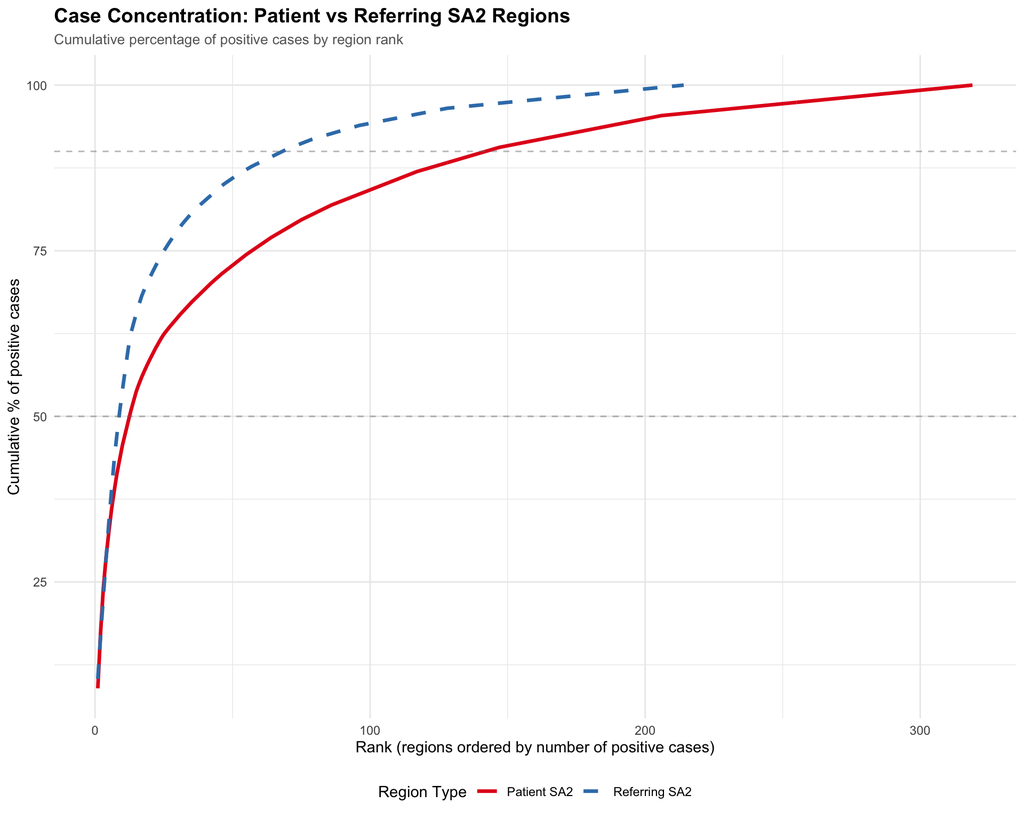

```r
# PLOT 2: Concentration curves comparing patient vs referring SA2 regions
# Prepare referring SA2 concentration data
ref_concentration <- ref_sa2_spatial %>%
  st_drop_geometry() %>%
  arrange(desc(cum_ref_pos_sa2)) %>%
  mutate(
    rank = row_number(),
    cumulative_pct = cumsum(cum_ref_pos_sa2) / sum(cum_ref_pos_sa2) * 100,
    type = "Referring SA2"
  ) %>%
  select(rank, cumulative_pct, type)

# Prepare patient SA2 concentration data
patient_concentration <- pat_sa2_spatial %>%
  st_drop_geometry() %>%
  arrange(desc(cum_pat_pos_sa2)) %>%
  mutate(
    rank = row_number(),
    cumulative_pct = cumsum(cum_pat_pos_sa2) / sum(cum_pat_pos_sa2) * 100,
    type = "Patient SA2"
  ) %>%
  select(rank, cumulative_pct, type)

# Combine data
concentration_data <- bind_rows(ref_concentration, patient_concentration)

# Create plot
concentration_plot <- ggplot(
  concentration_data,
  aes(x = rank, y = cumulative_pct, color = type, linetype = type)
) +
  geom_line(size = 1.2) +
  geom_hline(
    yintercept = 50,
    linetype = "dashed",
    color = "gray50",
    alpha = 0.5
  ) +
  geom_hline(
    yintercept = 90,
    linetype = "dashed",
    color = "gray50",
    alpha = 0.5
  ) +
  scale_color_manual(
    values = c("Patient SA2" = "#E41A1C", "Referring SA2" = "#377EB8")
  ) +
  scale_linetype_manual(
    values = c("Patient SA2" = "solid", "Referring SA2" = "dashed")
  ) +
  labs(
    title = "Case Concentration: Patient vs Referring SA2 Regions",
    subtitle = "Cumulative percentage of positive cases by region rank",
    x = "Rank (regions ordered by number of positive cases)",
    y = "Cumulative % of positive cases",
    color = "Region Type",
    linetype = "Region Type"
  ) +
  theme_minimal() +
  theme(
    plot.title = element_text(size = 14, face = "bold"),
    plot.subtitle = element_text(size = 10, color = "gray40"),
    legend.position = "bottom"
  )

print(concentration_plot)
```

```r
# Save plot
ggsave(
  "plots/concentration_curves_sa2.png",
  concentration_plot,
  width = 10,
  height = 6,
  dpi = 300
)
```